# Final-Tutorial

## Air Quality and Public Health Analysis

By Joshua Mathai

## Introduction

### Data Collection

To conduct this analysis, I collected two key datasets:

1. **Annual AQI by County for 2021**: This dataset was sourced from the EPA's Air Quality System (AQS). The EPA provides detailed information on air quality across the United States, which includes measurements of the Air Quality Index (AQI) at the county level. You can access and download this data directly from the [EPA website](https://aqs.epa.gov/aqsweb/airdata/download_files.html) by selecting the "Annual AQI by County" data for 2021.
2. **PLACES: Local Data for Better Health**: This dataset was obtained from the CDC's PLACES project, which offers health data at a granular level, including county and census tract levels. The CDC's PLACES data includes various health measures such as obesity, smoking, and access to healthcare. You can find and download this dataset from the [CDC website](https://www.cdc.gov/places/index.html).

### Purpose and Relevance

The primary aim of this analysis is to explore the relationship between air quality and public health outcomes. By combining AQI data from the EPA with health metrics from the CDC, I hope to identify patterns and correlations that can inform public health policies and interventions. This analysis is particularly relevant as it highlights how environmental factors like air quality can significantly impact community health.

Throughout this tutorial, I will demonstrate how to preprocess and clean these datasets, perform exploratory data analysis, and merge the data to generate insights. By the end of this tutorial, you will have a comprehensive understanding of how to handle real-world datasets and derive meaningful conclusions from them.

#### Step 1: Load the Data

First, I loaded the datasets into pandas DataFrames. The air quality data was sourced from the EPA, and the public health data was obtained from the CDC.

```python
import pandas as pd

# Load datasets
air_quality_data = pd.read_csv('/Users/joshuamathai/Desktop/CMSC320/annual_aqi_by_county_2021.csv')
public_health_data = pd.read_csv('/Users/joshuamathai/Desktop/CMSC320/PLACES__Local_Data_for_Better_Health__Census_Tract_Data_2023_release_20240518.csv')
```

#### Step 2: Inspect the Data

Before proceeding, I inspected the datasets to understand their structure and content. This included checking for missing values and ensuring the data types were appropriate.

```python
# Inspect the air quality data
print(air_quality_data.info())
print(air_quality_data.head())

# Inspect the public health data
print(public_health_data.info())
print(public_health_data.head())

# Check for missing values
print(air_quality_data.isnull().sum())
print(public_health_data.isnull().sum())
```

```
<class 'pandas.core.frame.DataFrame'>
RangeIndex: 1002 entries, 0 to 1001
Data columns (total 18 columns):
 #   Column                               Non-Null Count  Dtype
---  ------                               --------------  -----
 0   State                                1002 non-null   object
 1   County                               1002 non-null   object
 2   Year                                 1002 non-null   int64
 3   Days with AQI                        1002 non-null   int64
 4   Good Days                            1002 non-null   int64
 5   Moderate Days                        1002 non-null   int64
 6   Unhealthy for Sensitive Groups Days  1002 non-null   int64
 7   Unhealthy Days                       1002 non-null   int64
 8   Very Unhealthy Days                  1002 non-null   int64
 9   Hazardous Days                       1002 non-null   int64
 10  Max AQI                              1002 non-null   int64
 11  90th Percentile AQI                  1002 non-null   int64
 12  Median AQI                           1002 non-null   int64
 13  Days CO                              1002 non-null   int64
 14  Days NO2                             1002 non-null   int64
 15  Days Ozone                           1002 non-null   int64
 16  Days PM2.5                           1002 non-null   int64
 17  Days PM10                            1002 non-null   int64
dtypes: int64(16), object(2)
memory usage: 141.0+ KB
None
     State   County  Year  Days with AQI  Good Days  Moderate Days  \
0  Alabama  Baldwin  2021            280        264             16
1  Alabama     Clay  2021            110        101              9
2  Alabama   DeKalb  2021            361        331             30
3  Alabama   Elmore  2021            241        238              3
4  Alabama   Etowah  2021            286        253             33

   Unhealthy for Sensitive Groups Days  Unhealthy Days  Very Unhealthy Days  \
0                                    0               0                    0
1                                    0               0                    0
2                                    0               0                    0
3                                    0               0                    0
4                                    0               0                    0

```

[output cut: 108 more lines]

```
Data_Value_Unit                     0
Data_Value_Type                     0
Data_Value                          1
Data_Value_Footnote_Symbol    2555113
Data_Value_Footnote           2555113
Low_Confidence_Limit                1
High_Confidence_Limit               1
TotalPopulation                     0
Geolocation                         0
LocationID                          0
CategoryID                          0
MeasureId                           0
DataValueTypeID                     0
Short_Question_Text                 0
dtype: int64
```

#### Step 3: Rename Columns for Consistency

To ensure that the columns used for merging were named consistently across both datasets, I renamed the relevant columns in the air quality data.

```python
# Rename columns to ensure consistency
air_quality_data.rename(columns={'State': 'StateDesc', 'County': 'CountyName'}, inplace=True)
```

#### Step 4: Filter Data for the Relevant Year

The public health data included information for multiple years, but for this analysis, I focused on the year 2021. Therefore, I filtered the air quality data to include only records from 2021.

```python
# Filter air quality data to match the years in public health data (2021)
filtered_air_quality_data = air_quality_data[air_quality_data['Year'] == 2021]
```

#### Step 5: Clean and Standardize Key Columns

To ensure a successful merge, I cleaned the key columns (`StateDesc` and `CountyName`) by stripping any leading or trailing whitespace and standardizing the case.

```python
# Strip whitespace and ensure consistent case for merging keys
filtered_air_quality_data['StateDesc'] = filtered_air_quality_data['StateDesc'].str.strip().str.title()
filtered_air_quality_data['CountyName'] = filtered_air_quality_data['CountyName'].str.strip().str.title()
public_health_data['StateDesc'] = public_health_data['StateDesc'].str.strip().str.title()
public_health_data['CountyName'] = public_health_data['CountyName'].str.strip().str.title()
```

#### Step 6: Merge the Datasets

With the datasets prepared, I merged them on the common columns (`StateDesc`, `CountyName`, and `Year`). This step combines the air quality data with the corresponding public health data.

```python
# Merge datasets on StateDesc, CountyName, and Year
combined_data = pd.merge(filtered_air_quality_data, public_health_data, on=['StateDesc', 'CountyName', 'Year'], how='inner')

# Inspect the combined data
print("Combined data head:")
print(combined_data.head())
print("Combined data shape:", combined_data.shape)
```

```
Combined data head:
  StateDesc CountyName  Year  Days with AQI  Good Days  Moderate Days  \
0   Alabama    Baldwin  2021            280        264             16
1   Alabama    Baldwin  2021            280        264             16
2   Alabama    Baldwin  2021            280        264             16
3   Alabama    Baldwin  2021            280        264             16
4   Alabama    Baldwin  2021            280        264             16

   Unhealthy for Sensitive Groups Days  Unhealthy Days  Very Unhealthy Days  \
0                                    0               0                    0
1                                    0               0                    0
2                                    0               0                    0
3                                    0               0                    0
4                                    0               0                    0

   Hazardous Days  ...  Data_Value_Footnote  Low_Confidence_Limit  \
0               0  ...                  NaN                  29.8
1               0  ...                  NaN                  22.4
2               0  ...                  NaN                  76.5
3               0  ...                  NaN                   5.1
4               0  ...                  NaN                   4.0

   High_Confidence_Limit  TotalPopulation                       Geolocation  \
0                   40.9             4487  POINT (-87.87730464 30.43411562)
1                   29.8             3325   POINT (-87.7680448 30.84936067)
2                   82.6             6831  POINT (-87.57691343 30.56650746)
3                    8.7             8397   POINT (-87.84199987 30.5230855)
4                    5.3             4895  POINT (-87.45998999 30.41759256)

   LocationID  CategoryID  MeasureId DataValueTypeID   Short_Question_Text
0  1003011300     HLTHOUT    OBESITY          CrdPrv               Obesity
1  1003010600     RISKBEH   CSMOKING          CrdPrv       Current Smoking
2  1003010904     PREVENT      BPMED          CrdPrv  Taking BP Medication
3  1003011101     PREVENT    ACCESS2          CrdPrv      Health Insurance
4  1003011602     DISABLT   SELFCARE          CrdPrv  Self-care Disability

[5 rows x 38 columns]
Combined data shape: (1522065, 38)
```

#### Step 7: Select Relevant Columns

To focus the analysis, I selected the relevant columns from the merged dataset. This included the state and county identifiers, the year, the maximum AQI value, the health measure, and the corresponding data value.

```python
# Select relevant columns for analysis
columns_to_keep = ['StateDesc', 'CountyName', 'Year', 'Max AQI', 'Measure', 'Data_Value']
filtered_data = combined_data[columns_to_keep]
```

#### Step 8: Save the Processed Data

Finally, I saved the processed and filtered data to a new CSV file for further analysis.

```python
# Save the filtered data to a new CSV file
filtered_data.to_csv('/Users/joshuamathai/Desktop/CMSC320/filtered_data.csv', index=False)

# Display the first few rows of the filtered data
print(filtered_data.head())
```

```
  StateDesc CountyName  Year  Max AQI  \
0   Alabama    Baldwin  2021       61
1   Alabama    Baldwin  2021       61
2   Alabama    Baldwin  2021       61
3   Alabama    Baldwin  2021       61
4   Alabama    Baldwin  2021       61

                                             Measure  Data_Value
0               Obesity among adults aged >=18 years        35.1
1       Current smoking among adults aged >=18 years        26.1
2  Taking medicine for high blood pressure contro...        79.7
3  Current lack of health insurance among adults ...         6.7
4  Self-care disability among adults aged >=18 years         4.6
```

By following these steps, I ensured that the data was clean, consistent, and ready for analysis. The merged dataset now contains valuable information on air quality and public health measures, enabling us to explore potential correlations and insights.

### Summary

In this part of the tutorial, I walked through the data processing steps required to prepare the air quality and public health datasets for analysis. These steps included loading and inspecting the data, renaming columns for consistency, filtering data for the relevant year, cleaning and standardizing key columns, merging the datasets, selecting relevant columns, and saving the processed data. These preparations are essential for ensuring the accuracy and reliability of the analysis that follows.

### Exploratory Analysis and Data Vis

In this section, I'll perform exploratory data analysis and create visualizations to uncover patterns and insights from the merged dataset. This process involves summarizing the data, identifying key trends, and visualizing relationships between variables.

#### Step 1: Load the Processed Data

First, I'll load the processed data that was saved in the previous section.

```python
# Load the processed data
filtered_data = pd.read_csv('/Users/joshuamathai/Desktop/CMSC320/filtered_data.csv')

# Display the first few rows of the data
print(filtered_data.head())
```

```
  StateDesc CountyName  Year  Max AQI  \
0   Alabama    Baldwin  2021       61
1   Alabama    Baldwin  2021       61
2   Alabama    Baldwin  2021       61
3   Alabama    Baldwin  2021       61
4   Alabama    Baldwin  2021       61

                                             Measure  Data_Value
0               Obesity among adults aged >=18 years        35.1
1       Current smoking among adults aged >=18 years        26.1
2  Taking medicine for high blood pressure contro...        79.7
3  Current lack of health insurance among adults ...         6.7
4  Self-care disability among adults aged >=18 years         4.6
```

#### Step 2: Summary Statistics

To understand the basic characteristics of the data, I'll generate summary statistics for the numerical columns.

```python
# Generate summary statistics
print(filtered_data.describe())
```

```
            Year       Max AQI    Data_Value
count  1522065.0  1.522065e+06  1.522065e+06
mean      2021.0  1.487578e+02  2.101216e+01
std          0.0  7.039326e+01  2.143977e+01
min       2021.0  2.100000e+01  3.000000e-01
25%       2021.0  1.050000e+02  6.700000e+00
50%       2021.0  1.380000e+02  1.340000e+01
75%       2021.0  1.560000e+02  2.610000e+01
max       2021.0  2.723000e+03  9.790000e+01
```

#### Step 3: Distribution of Air Quality Index (AQI)

I'll visualize the distribution of the maximum AQI values to understand the overall air quality across different counties.

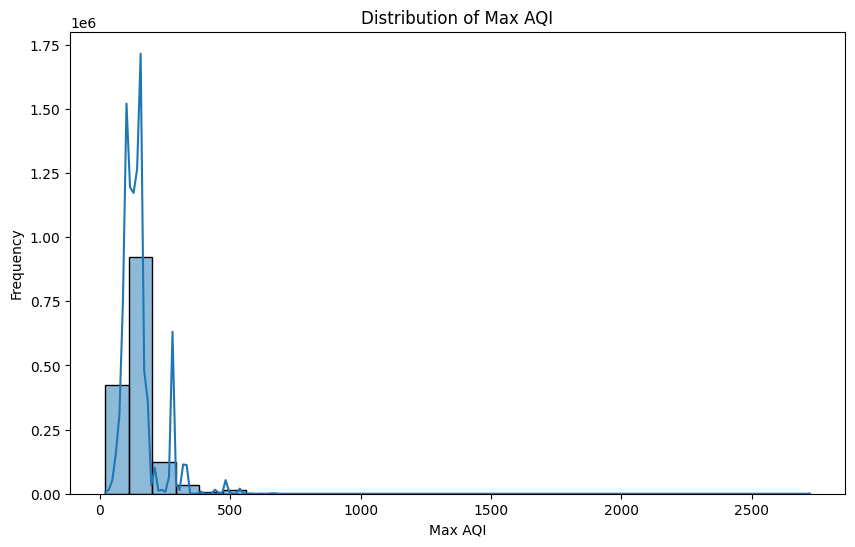

```python
import pandas as pd
import matplotlib.pyplot as plt
import seaborn as sns

# Plot the distribution of Max AQI
plt.figure(figsize=(10, 6))
sns.histplot(filtered_data['Max AQI'], bins=30, kde=True)
plt.title('Distribution of Max AQI')
plt.xlabel('Max AQI')
plt.ylabel('Frequency')
plt.show()
```

#### Step 4: Distribution of Health Measures

Next, I'll visualize the distribution of the health data values to see the prevalence of different health measures.

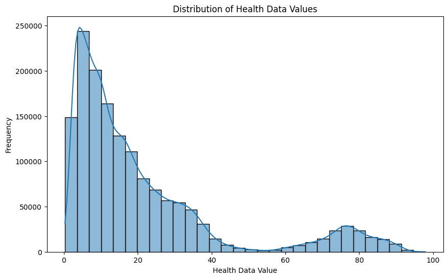

```python
# Plot the distribution of health data values
plt.figure(figsize=(10, 6))
sns.histplot(filtered_data['Data_Value'], bins=30, kde=True)
plt.title('Distribution of Health Data Values')
plt.xlabel('Health Data Value')
plt.ylabel('Frequency')
plt.show()
```

#### Step 5: Relationship Between AQI and Health Measures

To explore the relationship between air quality and public health measures, I'll create scatter plots showing the relationship between the maximum AQI and different health measures.

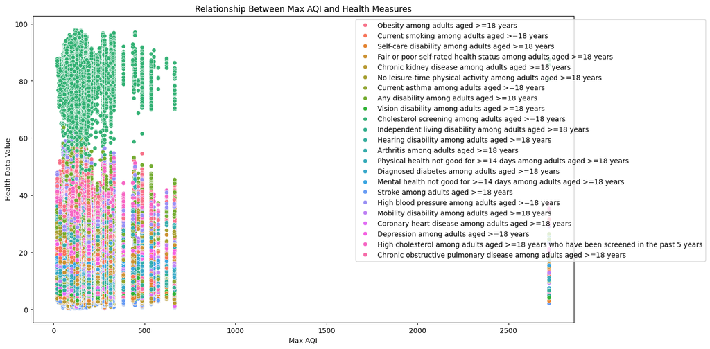

```python
relevant_measures = [
    'Obesity among adults aged >=18 years',
    'Current smoking among adults aged >=18 years',
    'Taking medicine for high blood pressure control among adults aged >=18 years',
    'Self-care disability among adults aged >=18 years',
    'Fair or poor self-rated health status among adults aged >=18 years',
    'Chronic kidney disease among adults aged >=18 years',
    'No leisure-time physical activity among adults aged >=18 years',
    'Current asthma among adults aged >=18 years',
    'Any disability among adults aged >=18 years',
    'Cognitive disability among adults aged >=18 years',
    'Vision disability among adults aged >=18 years',
    'Cholesterol screening among adults aged >=18 years',
    'Independent living disability among adults aged >=18 years',
    'Hearing disability among adults aged >=18 years',
    'Arthritis among adults aged >=18 years',
    'Physical health not good for >=14 days among adults aged >=18 years',
    'Diagnosed diabetes among adults aged >=18 years',
    'Mental health not good for >=14 days among adults aged >=18 years',
    'Stroke among adults aged >=18 years',
    'High blood pressure among adults aged >=18 years',
    'Mobility disability among adults aged >=18 years',
    'Coronary heart disease among adults aged >=18 years',
    'Depression among adults aged >=18 years',
    'High cholesterol among adults aged >=18 years who have been screened in the past 5 years',
    'Chronic obstructive pulmonary disease among adults aged >=18 years'
]

# Filter the data to include only relevant health measures
filtered_relevant_data = filtered_data[filtered_data['Measure'].isin(relevant_measures)]

# Scatter plot of Max AQI vs. Health Data Value for relevant measures
plt.figure(figsize=(14, 8))
sns.scatterplot(x='Max AQI', y='Data_Value', hue='Measure', data=filtered_relevant_data)
plt.title('Relationship Between Max AQI and Health Measures')
plt.xlabel('Max AQI')
plt.ylabel('Health Data Value')
plt.legend(loc='upper right', bbox_to_anchor=(1.25, 1))
plt.show()
```

#### Step 6: Health Measure Specific Analysis

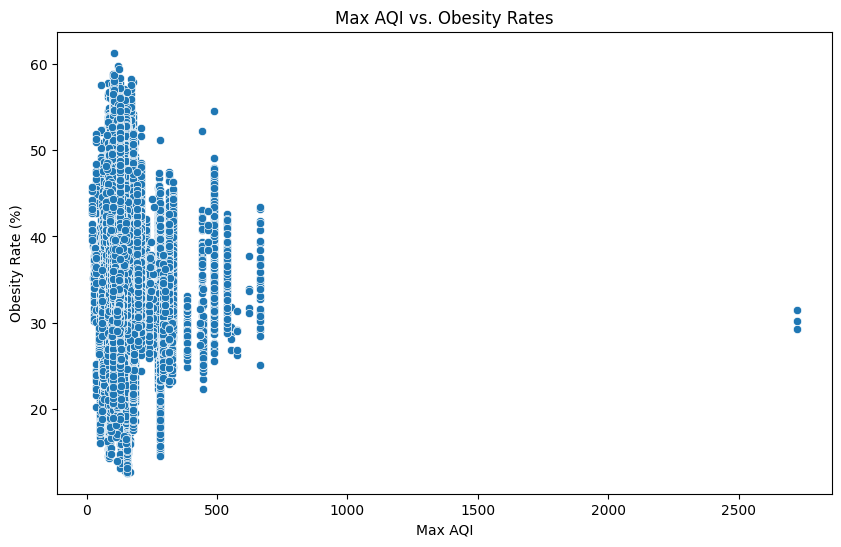

```python
# Filter data for specific health measures
obesity_data = filtered_data[filtered_data['Measure'].str.contains('Obesity')]
smoking_data = filtered_data[filtered_data['Measure'].str.contains('Smoking')]

# Plot Max AQI vs. Obesity
plt.figure(figsize=(10, 6))
sns.scatterplot(x='Max AQI', y='Data_Value', data=obesity_data)
plt.title('Max AQI vs. Obesity Rates')
plt.xlabel('Max AQI')
plt.ylabel('Obesity Rate (%)')
plt.show()
```

#### Step 7: Correlation Analysis

Finally, I'll perform a correlation analysis to quantify the relationship between air quality and health measures.

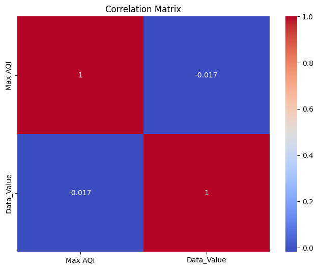

```python
# Calculate the correlation matrix
correlation_matrix = filtered_data[['Max AQI', 'Data_Value']].corr()

# Plot the correlation matrix
plt.figure(figsize=(8, 6))
sns.heatmap(correlation_matrix, annot=True, cmap='coolwarm')
plt.title('Correlation Matrix')
plt.show()
```

### Analysis, Hypothesis Testing, & ML Section

In this section, I'll demonstrate how to build a linear regression model to analyze the relationship between AQI (Air Quality Index) and a health measure (e.g., smoking rates). We'll go through the following steps:

1. **Prepare the data for modeling**.
2. **Split the data into training and testing sets**.
3. **Build and train a linear regression model**.
4. **Evaluate the model's performance**.

### Step 1: Prepare the Data for Modeling

First, let's ensure that the data is properly prepared and contains no missing values for the variables we are going to use.

```python
import numpy as np

filtered_data = pd.read_csv('/Users/joshuamathai/Desktop/CMSC320/filtered_data.csv')

# Define the measure for smoking rates
smoking_measure = 'Current smoking among adults aged >=18 years'

# Filter the data for smoking rates
smoking_data = filtered_data[filtered_data['Measure'] == smoking_measure]

# Check for missing values in the smoking data
print("Missing values in smoking data:")
print(smoking_data.isnull().sum())

# Drop rows with missing values (if any)
smoking_data = smoking_data.dropna()

# Verify the data after cleaning
print(smoking_data.head())
```

```
Missing values in smoking data:
StateDesc     0
CountyName    0
Year          0
Max AQI       0
Measure       0
Data_Value    0
dtype: int64
   StateDesc CountyName  Year  Max AQI  \
1    Alabama    Baldwin  2021       61
19   Alabama    Baldwin  2021       61
30   Alabama    Baldwin  2021       61
40   Alabama    Baldwin  2021       61
52   Alabama    Baldwin  2021       61

                                         Measure  Data_Value
1   Current smoking among adults aged >=18 years        26.1
19  Current smoking among adults aged >=18 years        16.5
30  Current smoking among adults aged >=18 years        17.4
40  Current smoking among adults aged >=18 years        11.8
52  Current smoking among adults aged >=18 years        12.9
```

### Step 2: Split the Data into Training and Testing Sets

Next, we'll split the data into training and testing sets. This allows us to train the model on one portion of the data and evaluate its performance on another.

```python
from sklearn.model_selection import train_test_split

# Define the feature (X) and target (y)
X = smoking_data[['Max AQI']]
y = smoking_data['Data_Value']

# Split the data into training and testing sets (80% training, 20% testing)
X_train, X_test, y_train, y_test = train_test_split(X, y, test_size=0.2, random_state=42)
```

### Step 3: Build and Train a Linear Regression Model

We will use the `LinearRegression` class from Scikit-Learn to build and train the model.

```python
from sklearn.linear_model import LinearRegression

# Initialize the linear regression model
model = LinearRegression()

# Train the model on the training data
model.fit(X_train, y_train)

# Print the coefficients
print("Coefficient:", model.coef_)
print("Intercept:", model.intercept_)
```

```
Coefficient: [-0.01307648]
Intercept: 17.57264374455587
```

### Step 4: Evaluate the Model's Performance

We will evaluate the model's performance using metrics such as R-squared and Mean Squared Error (MSE).

```
Mean Squared Error: 34.5398163476984
R-squared: 0.027059058741747744
```

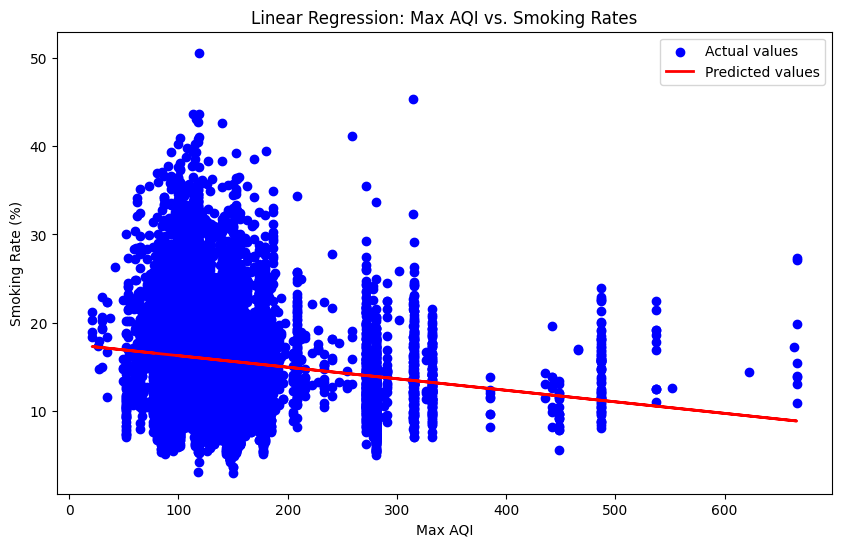

```python
from sklearn.metrics import mean_squared_error, r2_score

# Predict the target values for the test set
y_pred = model.predict(X_test)

# Calculate evaluation metrics
mse = mean_squared_error(y_test, y_pred)
r2 = r2_score(y_test, y_pred)

print("Mean Squared Error:", mse)
print("R-squared:", r2)

# Plot the results
plt.figure(figsize=(10, 6))
plt.scatter(X_test, y_test, color='blue', label='Actual values')
plt.plot(X_test, y_pred, color='red', linewidth=2, label='Predicted values')
plt.title('Linear Regression: Max AQI vs. Smoking Rates')
plt.xlabel('Max AQI')
plt.ylabel('Smoking Rate (%)')
plt.legend()
plt.show()
```

### Summary

In this section, we performed the following steps:

1. **Prepared the Data**: Cleaned the data and ensured there were no missing values.
2. **Split the Data**: Divided the data into training and testing sets.
3. **Built and Trained the Model**: Used linear regression to model the relationship between AQI and smoking rates.
4. **Evaluated the Model**: Assessed the model's performance using R-squared and Mean Squared Error, and visualized the results.

This simple linear regression model helps us understand the relationship between air quality and smoking rates. You can extend this analysis to other health measures to explore their relationships with AQI.